# Challenge 4

Customising figures

**Learning objectives**

- Figure sizes
- Figure captions
- Inserting images

```r
library(tidyverse)

knitr::opts_chunk$set(
  fig.path   ='figure/',
  fig.align  ='center',
  fig.retina = 2
)
```

There is a data set called `cars` that is loaded into R. You can have a look at the data set by typing `cars` into R.

```r
cars
```

```
##    speed dist
## 1      4    2
## 2      4   10
## 3      7    4
## 4      7   22
## 5      8   16
## 6      9   10
## 7     10   18
## 8     10   26
## 9     10   34
## 10    11   17
## 11    11   28
## 12    12   14
## 13    12   20
## 14    12   24
```

[output cut: 36 more lines]

I can get a scatter plot of the `speed` vs `dist` using `ggplot2` (which was loaded with `tidyverse`):

```r
ggplot(cars, aes(dist, speed)) +
  geom_point()
```

[output not shown]

## Figure sizes

By default the figure width is 7 inches and figure width is 5 inches for `html_document` output. You can change this to say 1 inch by setting the chunk options `fig.height = 1, fig.width = 1`. The values for `fig.height` and `fig.width` are required to be both numeric (measured in inches).

```r
ggplot(cars, aes(dist, speed)) +
  geom_point()
```

[output not shown]

Another way to scale your image is using `out.width` and `out.height`. These two options can only take character as values and this may depend on the output format. E.g. you can use `".8\\linewidth"`for pdf output (`\linewidth` is a LaTeX command) or `"300px"` for html output. You may also use percentage which scales appropriately for both html and pdf outputs. Below figure we use `out.width = "60%", out.height = "60%"`.

```r
ggplot(cars, aes(dist, speed)) +
  geom_point()
```

[output not shown]

We can use `fig.width` and `fig.height` with `out.width` and `out.height`. Below we have `fig.width = 3, fig.height = 3, out.width = "60%", out.height = "60%"`.

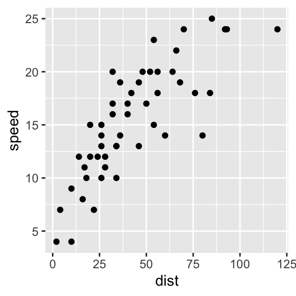

```r
ggplot(cars, aes(dist, speed)) +
  geom_point()
```

Getting the figure to “look” right usually requires playing around with these options.

❓ **What happens if your code chunk generates multiple figures?**

## Figure alignment

You may have noticed but in the global chunk I have set `fig.align = "center"` so that the figures will be centered as default.

The other valid values are `default` (no alignment), `left` and `right`. Below figure has `fig.align = "left"`.

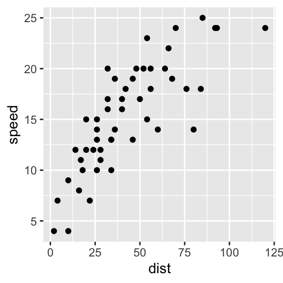

```r
ggplot(cars, aes(dist, speed)) +
  geom_point()
```

🔧 **Try changing the above figure so that the alignment is on the right instead.**

## Figure caption

You can include a figure caption by using the chunk option `fig.cap`.

```r
ggplot(cars, aes(dist, speed)) +
  geom_point()
```

[output not shown]

This is a boring scatter plot

Chunk options must be written in one line. This means that you cannot add a line break. This can make the line awkwardly long when you need to write a long caption.

Remember that chunk option values accept valid R expressions. As one work around, you can define a string variable, say `cap`, that contains the long caption as an inline R command. Then you can set option as `fig.cap = cap`. This is how the below caption was generated. Study the Rmd source code for how the caption was generated.

```r
ggplot(cars, aes(dist, speed)) +
  geom_point()
```

[output not shown]

This is some really long text that may be hard to fit within the chunk option.

If using `bookdown` output formats then there is another way to deal with these long captions [as described in the bookdown book](https://bookdown.org/yihui/bookdown/markdown-extensions-by-bookdown.html#text-references). We’ll come back to this later.

## Exporting the figures

❓ **Do you notice something about the figure names in the `figure` folder?** Don’t fret if you don’t. We’ll come back to this point later.

## Inserting images

To insert images in markdown, you can use `![](/path/to/your/image)`. The following logo is inserted using markdown syntax:

[figure not shown]

However to apply captions and images resizing as before, you want to insert the image via a chunk using `knitr::include_graphics()` as below.

```r
knitr::include_graphics("rlogo.svg")
```

[output not shown]

The logo of statistical software R

Plot & image customisation takes a number of tries to get it to look right. The huge advantage of R Markdown is that if you want to change the look of an image generated by code, this is easy - only requires some parameter change and knit again.

In the past, I had to

1. go to the script (which was separate to the document) that generated the figures;
2. change the parameter there;
3. generate the figures;
4. go back to document; and
5. compile the document.

Now I

1. go to my document;
2. change parameter setting; and
3. compile the document.

While it seems a small thing, there’s *friction in my workflow*. It’s worth investing to make your workflow smoother even if it takes time to learn initially. In the long term, you have more time on more important matters.

❓ **What tasks do you repea often or hinder productiveness in your work? Can you think of how to make your workflow smoother?**